# 线上平台用户分类分析

## 一、业务背景

某线上平台发现最近一年各类营销活动的效果不佳，且总体销售额没有明显的增长。据了解，以往的营销活动面向所有用户，部分用户无论有无营销活 动均稳定的消费，而有些用户很长时间未消费可能已转变为流失人群。平台逐渐意识到用户分类的重要性。实现用户分类后，可针对不同用户实施组合促销、会员卡充值、满减等营销活动。

## 二、数据说明

1. 案例中提供的数据为某电商平台的销售数据，数据来源于脱敏后的公开数据集
2. 数据表主要字段截图

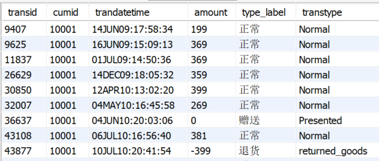

3. 主要字段含义：  
   transid：订单id  
   cumid: 用户id  
   trandatetime: 交易日期  
   amount ：订单金额  
   type_label：订单标签  
   transtype ：交易类型，与订单标签相对应

## 1.数据清洗

### 交易日期为明显的字符串格式，需要进行数据转换，为了便于后续操作，生成新表

```
create table rfmlabel_new as
    select
        transid,
        cumid,
        str_to_date(trandatetime,'%d%b%y:%H:%i:%s') as trandatetime,
        amount,
        type_label,
        transtype
    from rfmlabel;
```

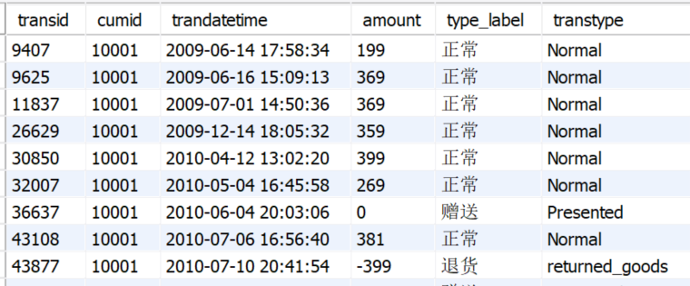

## 2. 确定数据分析的窗口期:

### （1）根据业务需求

这里为模拟数据所以不作考虑

### （2）数据窗口期选择 :

#### a. 尽可能覆盖多的用户(70%)

```
select max(trandatetime) from rfmlabel_new;
```

[output not shown]

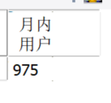

#### b.指标可计算有意义（F不能都为1）

```
  select
    cishu,
    count(*)
  from
	(select
        cumid,
        count(transid) as cishu
	from rfmlabel_new
	where trandatetime>date_sub('2010-09-26',interval 1 month)
	group by cumid)as 次数表
  group by cishu;
```

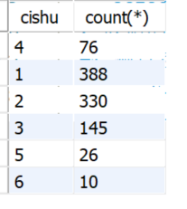

- F 值有多种，可见测算指标有意义

#### c.订单是有状态的，最近一个月的订单是否要考虑订单的状态

```
select distinct type_label from rfmlabel;
```

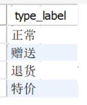

- 订单的状态有4种，我们选择正常、特价订单，便于精准分析意向购买人群

```
select
    *
from rfmlabel_new
where trandatetime>date_sub('2010-09-26',interval 1 month) and type_label in ('正常','特价');
```

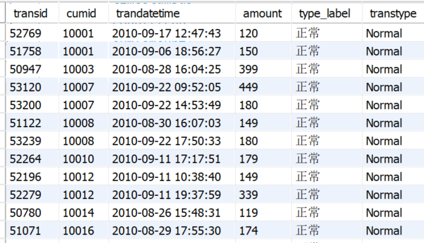

## 四、数据的统计分析

### 1. 计算每个顾客的RFM值

```
R=分析日期-最近一次购买日期
F=订单编号计数
M=订单金额合计
```

```
  select
	cumid,
        timestampdiff(day,max(trandatetime),'2010-09-26') as R,
        count(transid) as F,
        sum(amount) as M
   from rfmlabel_new
   where trandatetime>date_sub('2010-09-26',interval 1 month) and type_label in ('正常','特价')
   group by cumid;
```

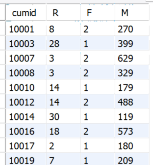

### 2.对指标进行分类分析

#### a.对R、F、M各指标进行二分类

```
R-->(远近）  F-->(高低）  M-->(高低）
```

#### b.二分类的阈值确定

- 作为连续型变量考虑用均值作为阈值
- 二分类口径:  
  R(远近）-------->如果用户R的值大于所有R的均值，则分类为为远，否则为近  
  F(高低）-------->如果用户F的值大于所有F的均值，则分类为为高，否则为低  
  M(高低）-------->如果用户M的值大于所有M的均值，则分类为为高，否则为低

#### c.查找分析

```
create table RFM as
with 指标表 as
(select
cumid,
timestampdiff(day,max(trandatetime),'2010-09-26') as R,
count(transid) as F,
sum(amount) as M
from rfmlabel_new where trandatetime>date_sub('2010-09-26',interval 1 month) and type_label in ('正常','特价')
group by cumid),
分类表 as
(select *,
if(R>avg(R) over(),'远','近') as R指标,
if(F>avg(F) over(),'高','低') as F指标,
if(M>avg(M) over(),'高','低') as M指标
from 指标表),
用户价值表 as
(select *,
 concat(R指标,F指标,M指标) as RFM标签,
case
   when concat(R指标,F指标,M指标)='近高高' then '重要价值用户'
   when concat(R指标,F指标,M指标)='近低高' then '重要发展用户'
   when concat(R指标,F指标,M指标)='远高高' then '重要保持用户'
   when concat(R指标,F指标,M指标)='远低高' then '重要挽留用户'
   when concat(R指标,F指标,M指标)='近高低' then '一般价值用户'
   when concat(R指标,F指标,M指标)='近低低' then '一般发展用户'
   when concat(R指标,F指标,M指标)='远高低' then '一般保持用户'
   else '一般挽留用户'
end as 用户价值
from 分类表)
select * from 用户价值表;
select * from RFM;
```

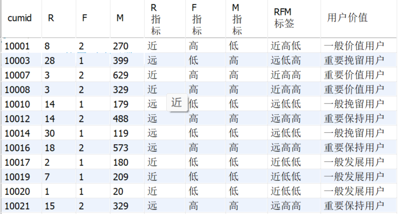

#### d.统计用户分类中各用户数量及其占比

```
select
    用户价值,
    count(cumid) as 用户数量,
    sum(M) 销售金额,
    concat(round(count(cumid) / sum(count(cumid)) over() *100,2) ,'%')as 占比
from rfm
group by 用户价值
order by 用户数量 desc;
```

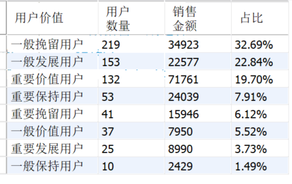

#### e.数据可视化

```python
import pandas as pd
import matplotlib.pyplot as plt
plt.style.use("seaborn-v0_8")
plt.rcParams["font.family"]='SimHei'
```

```python
user_value=pd.read_csv(".\shuju.csv")
user_value.sort_values(by='销售金额',ascending=False,inplace=True)
user_value.set_index('用户价值',inplace=True)
user_value
```

| 用户价值 | 用户数量 | 销售金额 | 占比 |
| --- | --- | --- | --- |
| 重要价值用户 | 132 | 71761 | 19.70% |
| 一般挽留用户 | 219 | 34923 | 32.69% |
| 重要保持用户 | 53 | 24039 | 7.91% |
| 一般发展用户 | 153 | 22577 | 22.84% |
| 重要挽留用户 | 41 | 15946 | 6.12% |
| 重要发展用户 | 25 | 8990 | 3.73% |
| 一般价值用户 | 37 | 7950 | 5.52% |
| 一般保持用户 | 10 | 2429 | 1.49% |

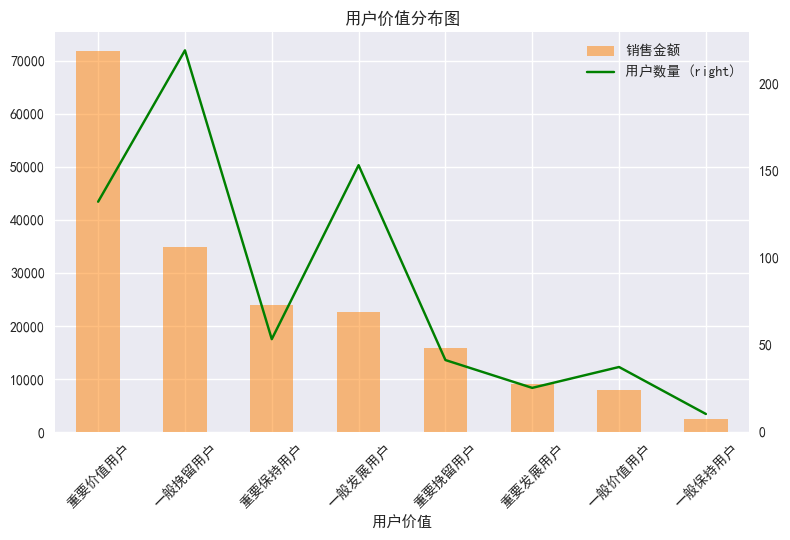

```python
user_value["销售金额"].plot(kind="bar", alpha=0.5,legend=True,title='用户价值分布图',color='#FF7F00')
user_value["用户数量"].plot(secondary_y=True, color="g", rot=45, legend=True)
plt.tight_layout()
```

## 五、用户价值（RFM）分层分析报告

### 1、分析背景与方法

本报告基于 **RFM 模型**（最近消费时间 R、消费频次 F、消费金额 M），将全量用户划分为 8 类价值群体，并结合销售金额与用户数量进行双维度评估，目的是回答三个问题：**钱从哪来、人在哪流失、预算该往哪投**。

### 2、数据全景

| 用户价值 | 用户数量 | 用户数占比 | 销售金额 | 销售额占比 | 人均贡献 |
| --- | --- | --- | --- | --- | --- |
| 重要价值用户 | 132 | 19.70% | 71,761 | 38.05% | 543.6 |
| 一般挽留用户 | 219 | 32.69% | 34,923 | 18.52% | 159.5 |
| 重要保持用户 | 53 | 7.91% | 24,039 | 12.75% | 453.6 |
| 一般发展用户 | 153 | 22.84% | 22,577 | 11.97% | 147.6 |
| 重要挽留用户 | 41 | 6.12% | 15,946 | 8.45% | 388.9 |
| 重要发展用户 | 25 | 3.73% | 8,990 | 4.77% | 359.6 |
| 一般价值用户 | 37 | 5.52% | 7,950 | 4.21% | 214.9 |
| 一般保持用户 | 10 | 1.49% | 2,429 | 1.29% | 242.9 |
| **合计** | **670** | **100%** | **188,615** | **100%** | **281.5** |

> 注：人均贡献 = 销售金额 ÷ 用户数量，反映单客消费力；因四舍五入，占比列合计约为 100%。

### 3、核心发现

**1. 典型的「二八效应」：少数高价值用户撑起大盘。** 「重要」四类用户合计 **251 人（37.5%）**，却贡献了 **120,736 元、占销售额 64.0%**；其中仅「重要价值用户」132 人（19.7%）就贡献 **38.0%** 的销售额。头部集中度高，核心用户的留存直接决定业绩基本盘。

**2. 「人多 ≠ 钱多」：人数峰值与销售峰值不在同一群体。** 人数最多的群体是**一般挽留用户（219 人，32.7%）**，而销售最高的群体是**重要价值用户（71,761 元）**。这说明单纯看用户规模会严重误判价值——必须做价值分层，而非按人头平均投入。

**3. 「重要 / 一般」本质是消费力分层，且分层有效。** 「重要」群体人均贡献普遍在 **359~544 元**，「一般」群体仅 **148~243 元**，两者存在清晰断层。模型成功把「高客单」与「低客单」用户区分开，可作为差异化运营的可靠依据。

**4. 存在一座「沉睡金矿」：重要保持用户。** 该群体仅 53 人，但**人均贡献高达 453.6 元（全榜第二）**，特征是「曾经高价值、近期沉默」。激活一名此类用户的回报，远高于拉新一名低价值用户，是性价比最高的增长机会。

**5. 腰部臃肿、升级链路不畅。** 「一般挽留 + 一般发展」合计 **372 人（55.5%）**，超过半数用户停留在低消费力层级，且人均贡献垫底。这提示「一般 → 重要」的用户培育 / 升级路径可能存在堵点，是中长期需打通的结构性问题。

### 4、分层运营策略

| 用户群体 | 特征画像 | 运营目标 | 关键动作 | 投入优先级 |
| --- | --- | --- | --- | --- |
| 重要价值用户 | 高客单·高频·近期活跃 | **守住**核心资产 | VIP 专属权益、1v1 客服、新品优先、防流失预警 | ★★★★★ |
| 重要保持用户 | 高客单·近期沉默 | **唤醒**沉睡金矿 | 大额定向召回券、专属关怀、爆品提醒 | ★★★★★ |
| 重要发展用户 | 高客单·低频 | **提频** | 会员积分加速、组合 / 交叉推荐、复购提醒 | ★★★★ |
| 重要挽留用户 | 高客单·流失边缘 | **紧急挽留** | 流失原因调研、挽回礼包、限时权益 | ★★★★ |
| 一般价值用户 | 中客单·活跃 | **提客单** | 满减门槛设计、向上销售、套餐组合 | ★★★ |
| 一般发展用户 | 低客单·活跃 | **规模化培育** | 自动化营销、习惯养成、提频提额任务 | ★★★ |
| 一般挽留用户 | 低客单·流失边缘 | **低成本试探** | 自动化触达，能救则救，不重投入 | ★★ |
| 一般保持用户 | 低客单·沉默 | **象征性维护** | 低频自动触达，几乎不投人工预算 | ★ |

### 5、资源分配建议

将营销预算与人力向**「重要保持 / 重要发展 / 重要挽留」**三类倾斜——它们人均贡献高、提升空间大，是「投入产出比」最优的杠杆点；对**「一般挽留 / 一般保持」**严格控制投入，以自动化、低成本方式覆盖即可。整体遵循「**按价值分配资源，而非按人数分配资源**」的原则。

### 6、结论与下一步行动

（1）. **结论**：用户结构呈「头部集中 + 腰部臃肿」特征，37.5% 的高价值用户贡献 64% 销售额；最大隐患是过半用户停留在低价值层级，最大机会是唤醒高人均的沉睡用户。  
（2）. **下一步行动**：

> 一句话总结：**把最多的资源，给最值得的人；让沉睡的高价值用户醒来，让活跃的低价值用户长大。**